# Assisgnement_Osborne_v2

The first part of the assignment asks us to create a sentence that ouputs “Hello, World”

```r
print("Hello, World")
```

```
## [1] "Hello, World"
```

Next, we’re going to set the working directory for the remainder of the assignment.

```r
setwd("/Users/Wizard/Dropbox/V_Fall 19/Data Science/Class/scripts_data_files")
```

Before going any further, we want to make sure that our global environment is clear and that we have installed the necessary libraries.

```r
## Clear environment
rm(list=ls())
## Get necessary libraries-- won't work the first time, because you need to install them!
library(tidyverse)
```

We will now load the data that we will need in order to complete the remainder of the questions in the problem set.

```r
load("college.Rdata")
```

We want to examine the difference in average earnings between selective and not very selective schools. After calculating the earnings for each of these two subsets, we will then compare.

```r
## What's the average earnings  for very selective schools?
sc%>%filter(adm_rate<.1)%>%summarize(mean_earnings=mean(md_earn_wne_p6,na.rm=TRUE))
```

```
## # A tibble: 1 x 1
##   mean_earnings
##           <dbl>
## 1         53500
```

```r
## And for not very selective schools?
sc%>%filter(adm_rate>.3)%>%summarize(mean_earnings=mean(md_earn_wne_p6,na.rm=TRUE))
```

```
## # A tibble: 1 x 1
##   mean_earnings
##           <dbl>
## 1        34747.
```

These findings suggest that average earnings at selective schools are approximately $18,752.86 more than average earnings at less selective schools

```r
#What's the average size for schools with high SAT scores?
sc%>%filter(sat_avg>1300)%>%summarize(avg_size=mean(ugds,na.rm=TRUE))
```

```
## # A tibble: 1 x 1
##   avg_size
##      <dbl>
## 1    6722.
```

```r
#What's the average size for schools with low SAT scores?
sc%>%filter(sat_avg<1100)%>%summarize(avg_size=mean(ugds,na.rm=TRUE))
```

```
## # A tibble: 1 x 1
##   avg_size
##      <dbl>
## 1    4816.
```

Next, we’ll be looking at whether there is a relationship between the cost of attending a school and the debt that a student leaves with. To do so, we will create a scatter plot using these two variables.

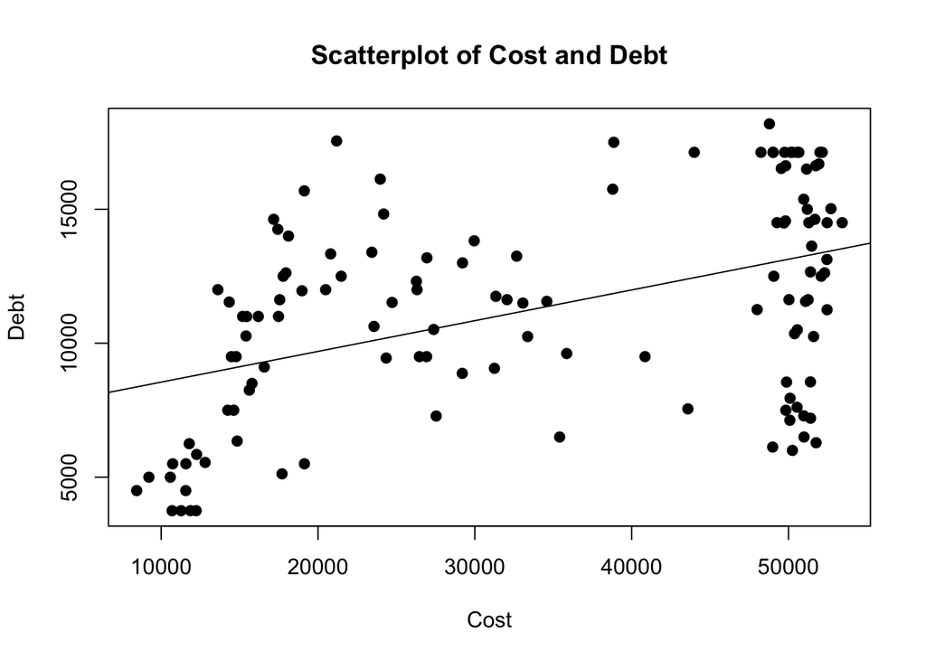

```r
plot(sc$costt4_a, sc$debt_mdn, main="Scatterplot of Cost and Debt", xlab ="Cost", ylab = "Debt", pch=19)
costdebt <- lm(debt_mdn ~ costt4_a, data = sc)
abline(costdebt)
```

Based on this plot, it looks like there is a positive relationship between the cost of a university and the amount of debt that a student graduates with.

Finally, we will create two separate scatter plots that examine whether there is a relationship between the control of a school (i.e., public, private not for profit, private for profit) and cost or debt. First up, its control and cost.

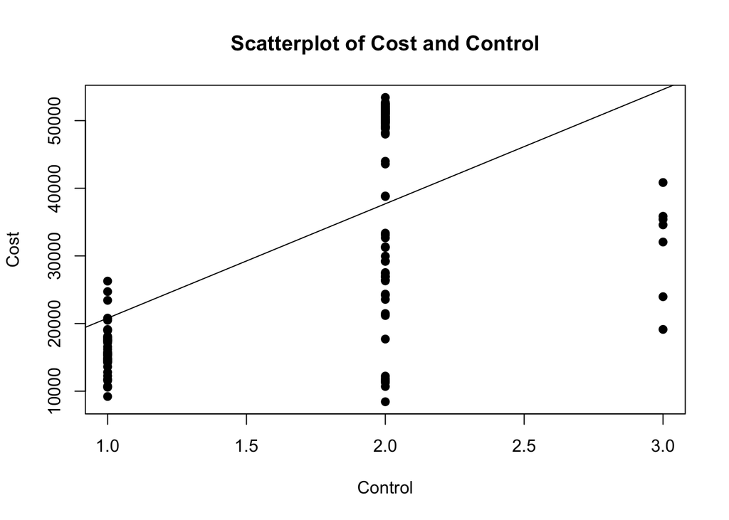

```r
plot(sc$control, sc$costt4_a, main="Scatterplot of Cost and Control", xlab ="Control", ylab = "Cost", pch=19)
costcontrol <- lm(costt4_a ~ control, data = sc)
abline(costcontrol)
```

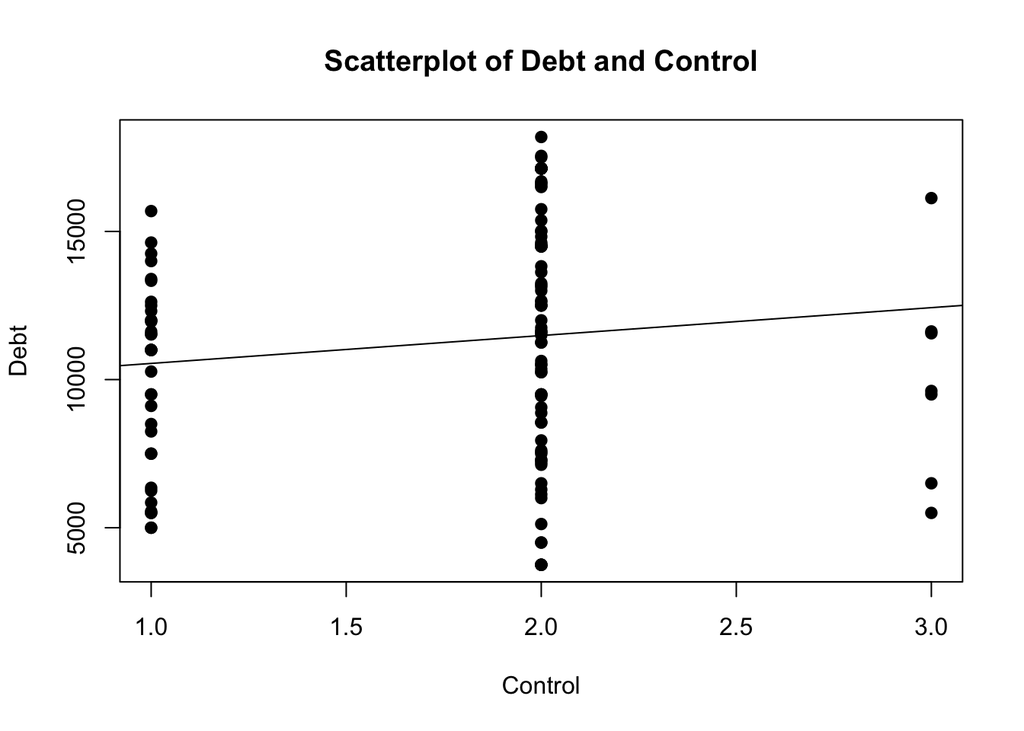

```r
plot(sc$control, sc$debt_mdn, main="Scatterplot of Debt and Control", xlab ="Control", ylab = "Debt", pch=19)
debtcontrol <- lm(debt_mdn ~ control, data = sc)
abline(debtcontrol)
```